# リサーチ方法論2-14

### 線形性（Linearity）

目的変数が説明変数と線形な関係を持つという条件。 Component plus residual プロットを使うと線形性を確認できる。

```r
par( mar = c( 4.5, 4.5, 3, 1 ) )
#マージンは、プロットエリア（グラフの描画領域）と図全体との間のスペースを指定。par(mar = c(4.5, 4.5, 3, 1))の引数c(4.5, 4.5, 3, 1)は、マージンの上部、下部、左側、右側のサイズを指定。
library(car)
```

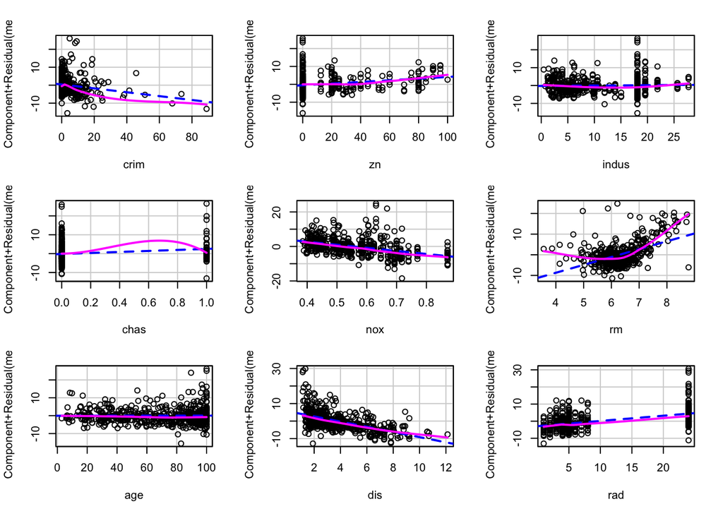

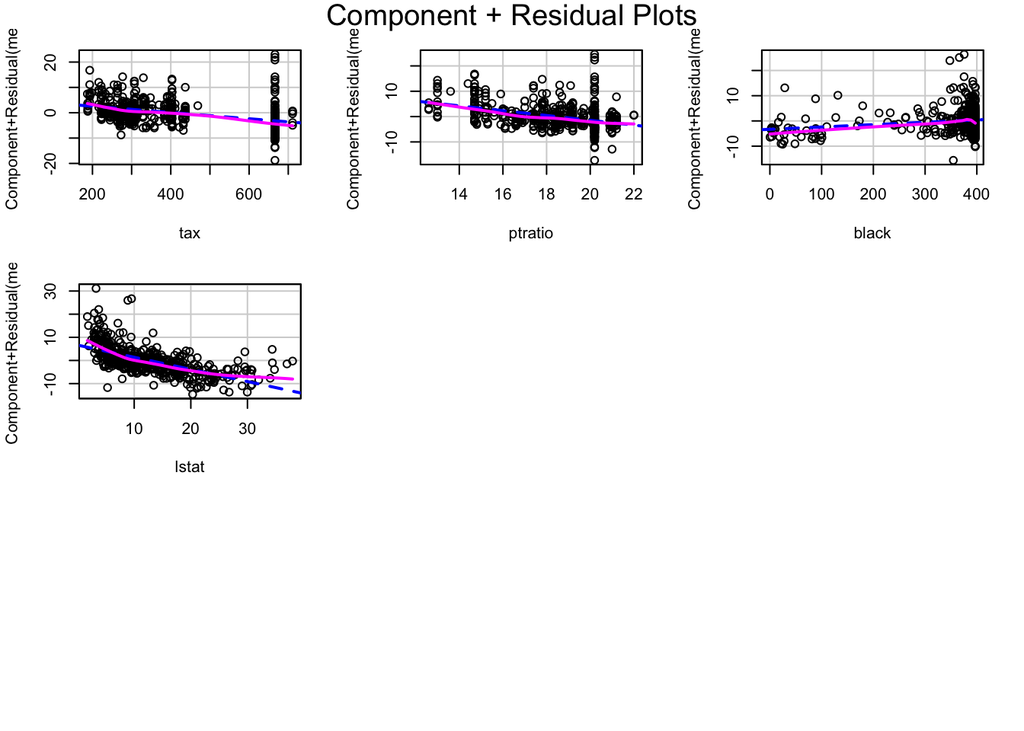

```r
crPlots( lmfit )
```

2つの線が重なっていれば、線形性が満たされる。 crim, chas, rm は重なっていない。

### 等分散性（Homoscedasticity）

目的変数の分散が位置によらず一定であるという条件。 もし等分散性が満たされていれば残差の値は予測値の値に依存しない（つまり水平な分布）になる

```r
library(car)
ncvTest( lmfit )
```

```
## Non-constant Variance Score Test
## Variance formula: ~ fitted.values
## Chisquare = 15.24407, Df = 1, p = 9.4473e-05
```

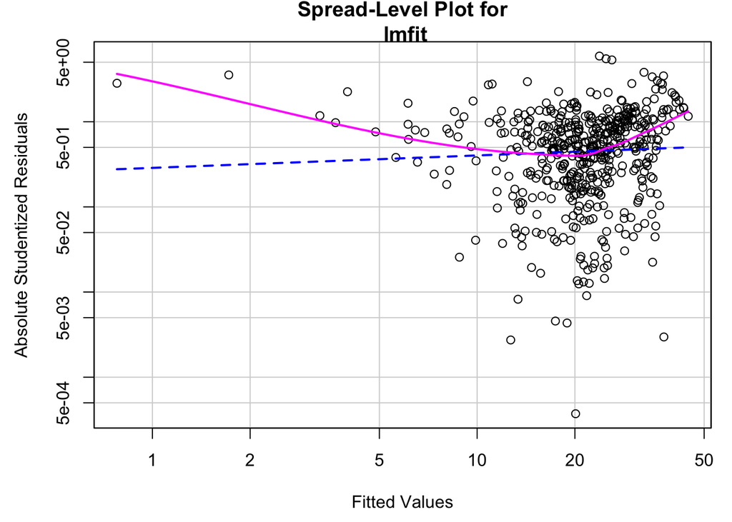

```
##
## Suggested power transformation:  0.8541632
```

```r
par( mar = c( 4.5, 4.5, 2, 1 ) )
spreadLevelPlot( lmfit )
```

p 値が 0.05 未満であり、等分散ではないという結果

http://stat.sys.i.kyoto-u.ac.jp/titech/class/dk2005/san08.pdfを参照しています。

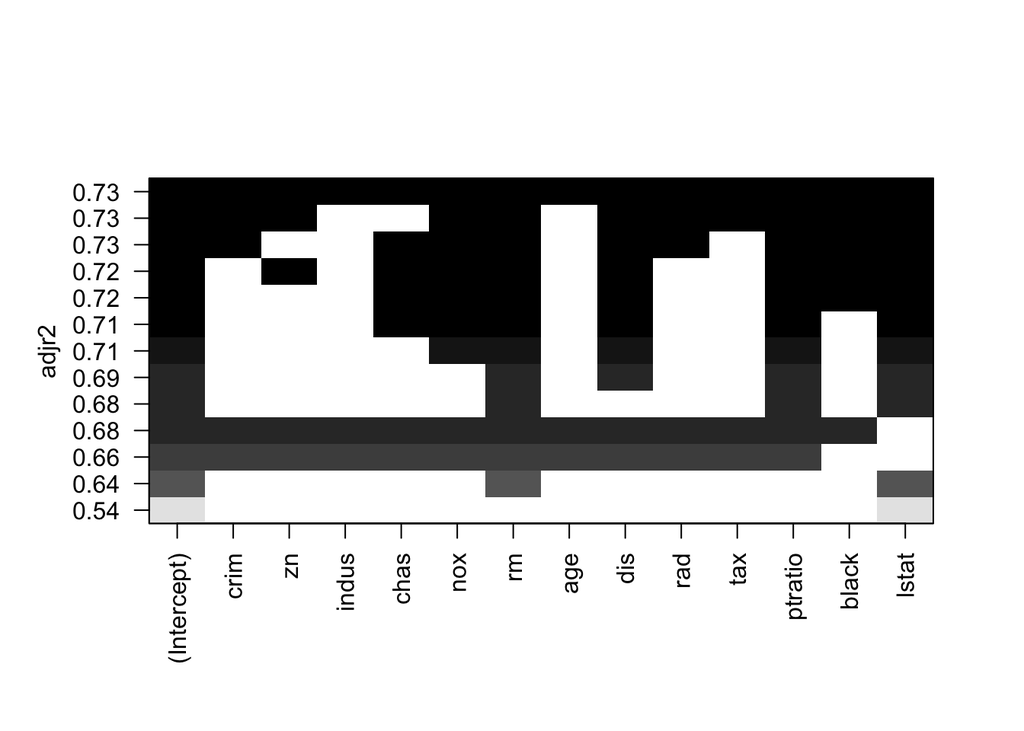

```r
library(leaps)
best<-regsubsets(medv~., data = Boston, nvmax = 13, method = "seqrep")
sbest<-summary(best)
plot(best,scale="adjr2")
```

```r
sbest$rss #これらのモデルのRSS(残差変動)
```

```
##  [1] 19472.38 15439.31 13727.99 13228.91 12469.34 12141.07 11868.24 11678.30
##  [9] 11526.12 11308.58 14082.96 13489.62 11078.78
```

```r
n<-ncol(Boston) #Bostonの変数の数をnとする
p<-nrow(sbest$which) #ベストモデルsbestの数
aicbest<- n*(1+log(2*pi*sbest$rss/n))+2*(2+(1:p)) #各モデルのAICの計算
aicbest #AICの表示
```

```
##  [1] 147.0580 145.8089 146.1642 147.6457 148.8179 150.4444 152.1262 153.9003
##  [9] 155.7167 157.4499 162.5216 163.9189 163.1625
```

```r
order(aicbest) #AICの小さい順に並べると2番目のモデルが最小
```

```
##  [1]  2  3  1  4  5  6  7  8  9 10 11 13 12
```

```r
sbest$which[2,] #2番目のモデルの変数の有無を表示。TRUEが採用する変数。
```

```
## (Intercept)        crim          zn       indus        chas         nox
##        TRUE       FALSE       FALSE       FALSE       FALSE       FALSE
##          rm         age         dis         rad         tax     ptratio
##        TRUE       FALSE       FALSE       FALSE       FALSE       FALSE
##       black       lstat
##       FALSE        TRUE
```

```r
aicbest[2] #2番目のモデルのAIC
```

```
## [1] 145.8089
```

medv~rm+lstatのモデルが最良という結果になった。 そのAICは145.8089

## 多重共線性の評価

```r
bestfit<-lm(medv~rm+lstat,data=Boston)
summary(bestfit)
```

```
##
## Call:
## lm(formula = medv ~ rm + lstat, data = Boston)
##
## Residuals:
##     Min      1Q  Median      3Q     Max
## -18.076  -3.516  -1.010   1.909  28.131
##
## Coefficients:
##             Estimate Std. Error t value Pr(>|t|)
## (Intercept) -1.35827    3.17283  -0.428    0.669
## rm           5.09479    0.44447  11.463   <2e-16 ***
## lstat       -0.64236    0.04373 -14.689   <2e-16 ***
## ---
## Signif. codes:  0 '***' 0.001 '**' 0.01 '*' 0.05 '.' 0.1 ' ' 1
##
## Residual standard error: 5.54 on 503 degrees of freedom
## Multiple R-squared:  0.6386, Adjusted R-squared:  0.6371
## F-statistic: 444.3 on 2 and 503 DF,  p-value: < 2.2e-16
```

```r
library(car)
vif(bestfit)
```

```
##      rm   lstat
## 1.60452 1.60452
```

```r
cor(Boston$rm, Boston$lstat)
```

```
## [1] -0.6138083
```

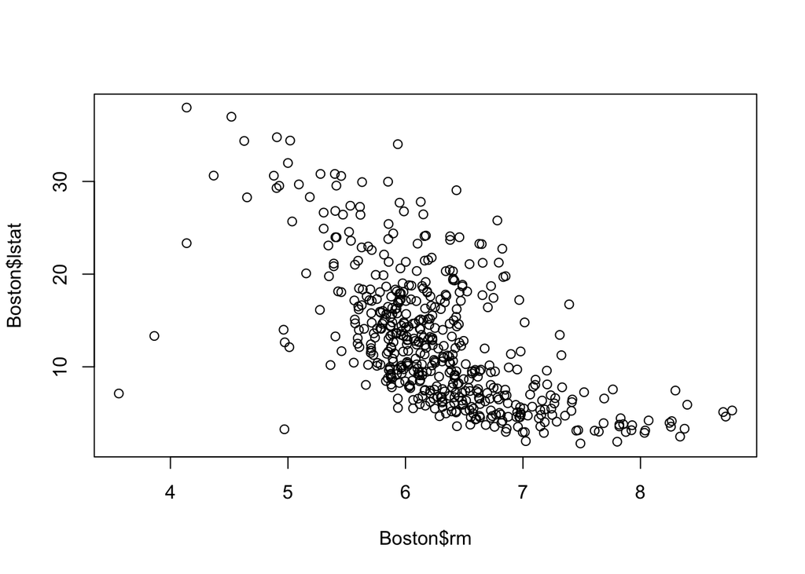

```r
plot(Boston$rm, Boston$lstat)
```

rm 1.60452 lstat 1.60452 となり、10を超えていないので多重共線性は見られない。

ただし、散布図と相関係数を見ると、-0.6程度で中程度の負の相関が見られる。

rm: 住居ごとの平均部屋数

lstat: 低所得者の割合

なので、住宅価格＝ 5.09479×住居ごとの平均部屋数-0.64236×低所得者の割合-1.35827

部屋数が増えれば住宅価格が上がり、低所得者の割合が増えれば、住宅価格が下がるという関係が見られる。

### 標準化回帰係数

```r
z = as.data.frame( scale(Boston) ) #scale関数で各列の値は平均0、標準偏差1の分布となる
zfit = lm( medv ~ rm + lstat, data = z )
options( scipen = 20 ) #表示される数値の指数表記の桁数（表示精度）を設定
summary( zfit )
```

```
##
## Call:
## lm(formula = medv ~ rm + lstat, data = z)
##
## Residuals:
##     Min      1Q  Median      3Q     Max
## -1.9654 -0.3823 -0.1098  0.2075  3.0587
##
## Coefficients:
##                         Estimate           Std. Error t value
## (Intercept)  0.00000000000000129  0.02677956880524802    0.00
## rm           0.38921875253899446  0.03395515341075680   11.46
## lstat       -0.49875703630006041  0.03395515341075676  -14.69
##                        Pr(>|t|)
## (Intercept)                   1
## rm          <0.0000000000000002 ***
## lstat       <0.0000000000000002 ***
## ---
## Signif. codes:  0 '***' 0.001 '**' 0.01 '*' 0.05 '.' 0.1 ' ' 1
##
## Residual standard error: 0.6024 on 503 degrees of freedom
## Multiple R-squared:  0.6386, Adjusted R-squared:  0.6371
## F-statistic: 444.3 on 2 and 503 DF,  p-value: < 0.00000000000000022
```

住宅価格＝ 0.389218752538994461343 ×住居ごとの平均部屋数-0.498757036300060407896 ×低所得者の割合+ 0.000000000000001289686

標準化することで、低所得者層の割合の方が平均部屋数より住宅価格にマイナスの影響を与えていることがわかる。

### その他注意点

このデータでは線形性と等分散性が見られない部分があった。 このような場合、説明変数の選択を行うほか、データの外れ値を抜いて回帰、目的変数の指数変換や対数変換を行う必要がある。 授業で取り扱うレベルを超えるので、下記に参考資料を示します。 https://htsuda.net/stats/regression.html#%E5%AF%BE%E5%87%A6%E6%96%B9%E6%B3%95